# IADL - Difficulties for managing money

# 1 Description of DataSchema variable

The description of harmonised variable is the following:

- Short name: `iadl_money`
- Variable label: `IADL - Difficulties for managing money, bills, expenses`
- Domain: `Health status and functional limitations`
- Value type: `categorical`
- Category coding:

| **Code** | **Category Label** |
| --- | --- |
| 0 | Yes |
| 1 | No |

- Category missings:

| **Code** | **Category Label** |
| --- | --- |
| 991 | CAPI/interviewer error |
| 992 | Impute |
| 993 | Disable to measure |
| 994 | Not attempt/not done |
| 995 | Does not answer |
| 996 | Not applicable |
| 997 | Refuse |
| 998 | Do not know |
| 999 | Missing |

# 2 Data process

## 2.1 England

### 2.1.1 Wave 1

- Name: `headlmo`
- Label: `IADL: Difficulty managing money, eg paying bills,keeping track expenses`
- Categories:
- `0 = Not mentioned`
- `1 = Mentioned`
- Missings
- `-9 = Refusal`
- `-8 = Don't know`
- `-1 = Not applicable`

| Sample size | Missing values |
| --- | --- |
| 12099 | 0 |

Category

|  | -9 | -8 | -1 | 0 | 1 |
| --- | --- | --- | --- | --- | --- |
| Frequency | 4.00 | 12.0 | 175.00 | 11620.00 | 288.00 |
| Percentage | 0.03 | 0.1 | 1.45 | 96.04 | 2.38 |

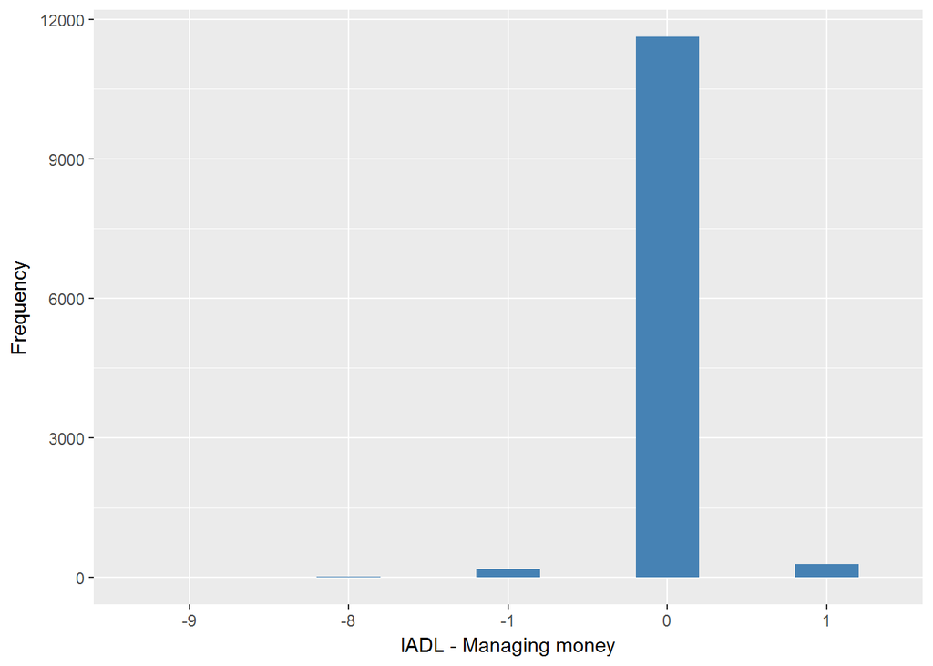

#### 2.1.1.1 Harmonisation algorithm

To compute the harmonize variable from the study-specific variable it has to be recoded as follows:

- `1 into 0`
- `0 into 1`
- `-9 Refusal into 997`
- `-8 Don't know into 998`
- `-1 Not applicable into 996`

**R script:**

```r
ELSA_ds_w1 <- tibble(id = ELSA_w1_iadl_money$id)
ELSA_ds_w1$iadl_money <- car::recode(ELSA_w1_iadl_money$headlmo, "0 = '1';1 = '0';-9 = '997';-8 = '998';-1 = '996' ")
ELSA_ds_w1$iadl_money <- labelled(ELSA_ds_w1$iadl_money, labels = c(Yes = 0,
    No = 1, Missing = 999, Do_not_know = 998, Refuse = 997, Not_applicable = 996,
    Does_not_answer = 995, Not_attempt_not_done = 994, Disable_to_measure = 993,
    Impute = 992, CAPI_interviewer_error = 991))
```

#### 2.1.1.2 Statistical description of the new harmonised variable

| Sample size | Missing values |
| --- | --- |
| 12099 | 191 |

Category

|  | 0 | 1 |
| --- | --- | --- |
| Frequency | 288.00 | 11620.00 |
| Percentage | 2.38 | 96.04 |

Type of missing

|  | 991 | 992 | 993 | 994 | 995 | 996 | 997 | 998 | 999 | NA |
| --- | --- | --- | --- | --- | --- | --- | --- | --- | --- | --- |
| Frequency | 0 | 0 | 0 | 0 | 0 | 175.00 | 4.00 | 12.0 | 0 | 0 |
| Percentage | 0 | 0 | 0 | 0 | 0 | 1.45 | 0.03 | 0.1 | 0 | 0 |

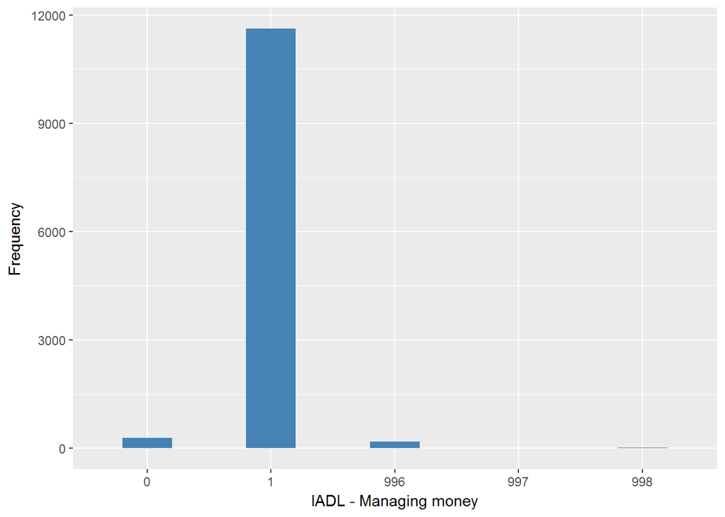

#### 2.1.1.3 Validation

|  | 1->0 | 0->1 | -1->996 | -9->997 | -8->998 |
| --- | --- | --- | --- | --- | --- |
| BeforeH | 288 | 11620 | 175 | 4 | 12 |
| AfterH | 288 | 11620 | 175 | 4 | 12 |

### 2.1.2 Wave 2

- Name: `headlmo`
- Label: `IADL: Difficulty managing money, eg paying bills,keeping track expenses`
- Categories:
- `0 = Not mentioned`
- `1 = Mentioned`
- Missings
- `-9 = Refusal`
- `-8 = Don't know`

| Sample size | Missing values |
| --- | --- |
| 9432 | 0 |

Category

|  | -9 | -8 | 0 | 1 |
| --- | --- | --- | --- | --- |
| Frequency | 2.00 | 1.00 | 9117.00 | 312.00 |
| Percentage | 0.02 | 0.01 | 96.66 | 3.31 |

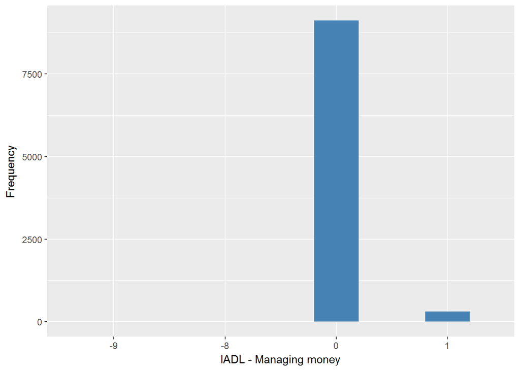

#### 2.1.2.1 Harmonisation algorithm

To compute the harmonize variable from the study-specific variable it has to be recoded as follows:

- `1 into 0`
- `0 into 1`
- `-9 Refusal into 997`
- `-8 Don't know into 998`

**R script:**

```r
ELSA_ds_w2 <- tibble(id = ELSA_w2_iadl_money$id)
ELSA_ds_w2$iadl_money <- car::recode(ELSA_w2_iadl_money$headlmo, "0 = '1';1 = '0';-9 = '997';-8 = '998';-1 = '996' ")
ELSA_ds_w2$iadl_money <- labelled(ELSA_ds_w2$iadl_money, labels = c(Yes = 0,
    No = 1, Missing = 999, Do_not_know = 998, Refuse = 997, Not_applicable = 996,
    Does_not_answer = 995, Not_attempt_not_done = 994, Disable_to_measure = 993,
    Impute = 992, CAPI_interviewer_error = 991))
```

#### 2.1.2.2 Statistical description of the new harmonised variable

| Sample size | Missing values |
| --- | --- |
| 9432 | 3 |

Category

|  | 0 | 1 |
| --- | --- | --- |
| Frequency | 312.00 | 9117.00 |
| Percentage | 3.31 | 96.66 |

Type of missing

|  | 991 | 992 | 993 | 994 | 995 | 996 | 997 | 998 | 999 | NA |
| --- | --- | --- | --- | --- | --- | --- | --- | --- | --- | --- |
| Frequency | 0 | 0 | 0 | 0 | 0 | 0 | 2.00 | 1.00 | 0 | 0 |
| Percentage | 0 | 0 | 0 | 0 | 0 | 0 | 0.02 | 0.01 | 0 | 0 |

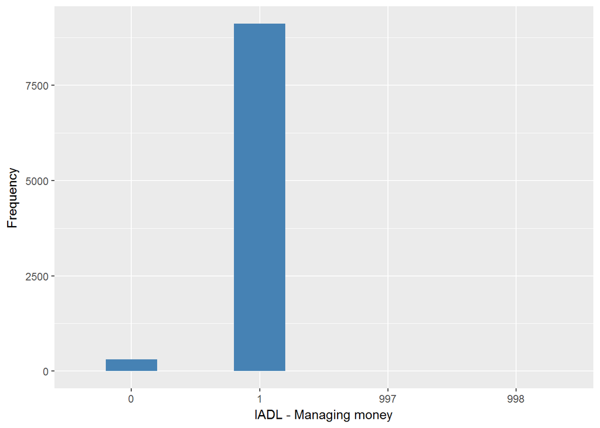

#### 2.1.2.3 Validation

|  | 1->0 | 0->1 | -9->997 | -8->998 |
| --- | --- | --- | --- | --- |
| BeforeH | 312 | 9117 | 2 | 1 |
| AfterH | 312 | 9117 | 2 | 1 |

### 2.1.3 Wave 3

- Name: `headlmo`
- Label: `IADL: Difficulty managing money, eg paying bills,keeping track expenses`
- Categories:
- `0 = Not mentioned`
- `1 = Mentioned`
- Missings
- `-1 = Not applicable`

HEADLMO

| Sample size | Missing values |
| --- | --- |
| 9771 | 0 |

Category

|  | -1 | 0 | 1 |
| --- | --- | --- | --- |
| Frequency | 4.00 | 9409.0 | 358.00 |
| Percentage | 0.04 | 96.3 | 3.66 |

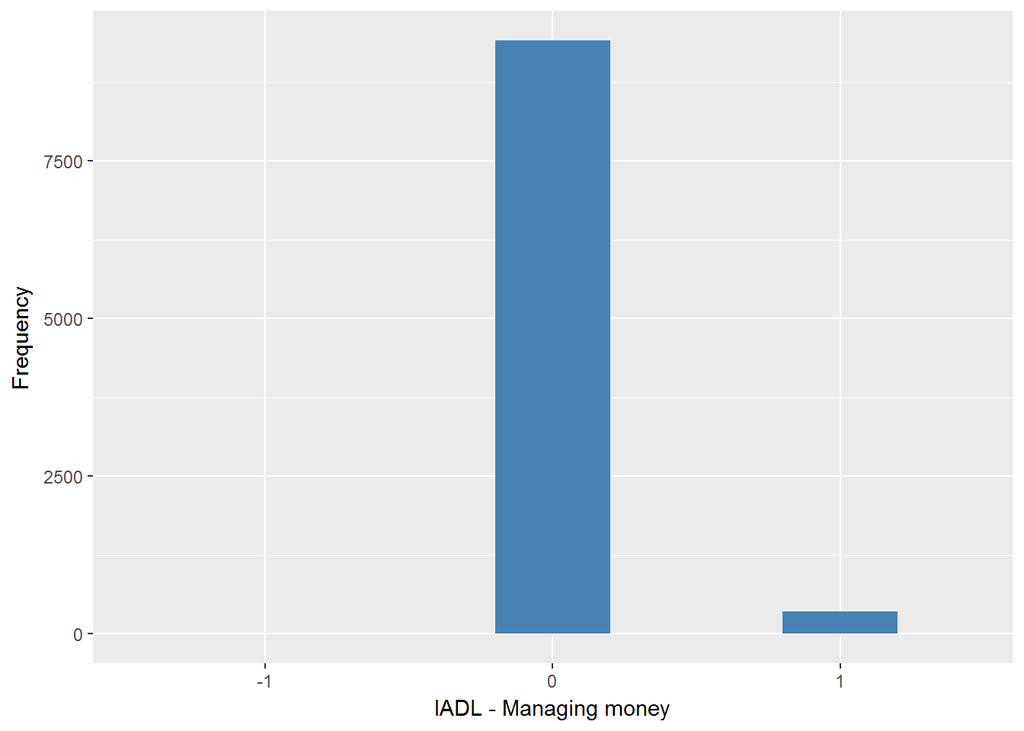

#### 2.1.3.1 Harmonisation algorithm

To compute the harmonize variable from the study-specific variable it has to be recoded as follows:

- `1 into 0`
- `0 into 1`
- `-1 Not applicable into 996`

**R script:**

```r
ELSA_ds_w3 <- tibble(id = ELSA_w3_iadl_money$id)
ELSA_ds_w3$iadl_money <- car::recode(ELSA_w3_iadl_money$headlmo, "0 = '1';1 = '0';-9 = '997';-8 = '998';-1 = '996' ")
ELSA_ds_w3$iadl_money <- labelled(ELSA_ds_w3$iadl_money, labels = c(Yes = 0,
    No = 1, Missing = 999, Do_not_know = 998, Refuse = 997, Not_applicable = 996,
    Does_not_answer = 995, Not_attempt_not_done = 994, Disable_to_measure = 993,
    Impute = 992, CAPI_interviewer_error = 991))
```

#### 2.1.3.2 Statistical description of the new harmonised variable

| Sample size | Missing values |
| --- | --- |
| 9771 | 4 |

Category

|  | 0 | 1 |
| --- | --- | --- |
| Frequency | 358.00 | 9409.0 |
| Percentage | 3.66 | 96.3 |

Type of missing

|  | 991 | 992 | 993 | 994 | 995 | 996 | 997 | 998 | 999 | NA |
| --- | --- | --- | --- | --- | --- | --- | --- | --- | --- | --- |
| Frequency | 0 | 0 | 0 | 0 | 0 | 4.00 | 0 | 0 | 0 | 0 |
| Percentage | 0 | 0 | 0 | 0 | 0 | 0.04 | 0 | 0 | 0 | 0 |

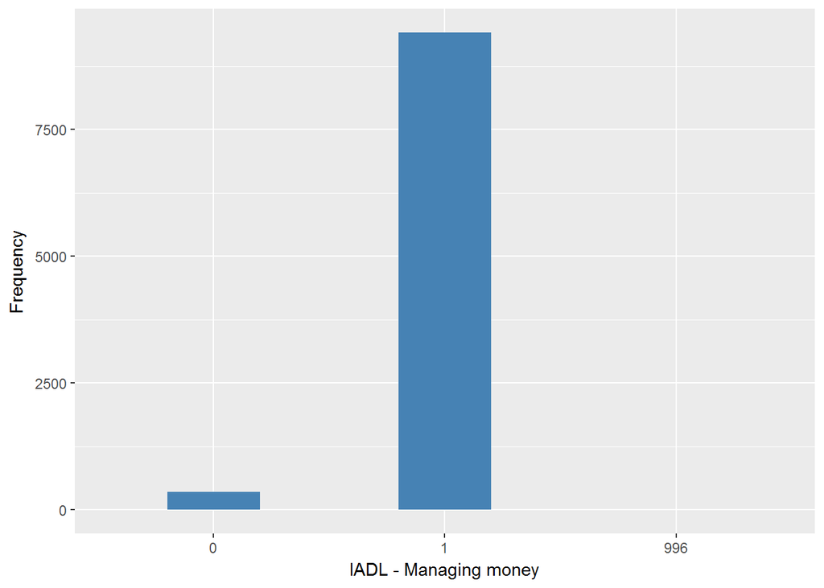

#### 2.1.3.3 Validation

|  | 1->0 | 0->1 | -1->996 |
| --- | --- | --- | --- |
| BeforeH | 358 | 9409 | 4 |
| AfterH | 358 | 9409 | 4 |

### 2.1.4 Wave 4

- Name: `headlmo`
- Label: `IADL: Difficulty managing money, eg paying bills,keeping track expenses`
- Categories:
- `0 = Not mentioned`
- `1 = Mentioned`
- Missings
- `-9 = Refusal`
- `-8 = Don't know`

| Sample size | Missing values |
| --- | --- |
| 11050 | 0 |

Category

|  | -9 | -8 | 0 | 1 |
| --- | --- | --- | --- | --- |
| Frequency | 7.00 | 2.00 | 10673.00 | 368.00 |
| Percentage | 0.06 | 0.02 | 96.59 | 3.33 |

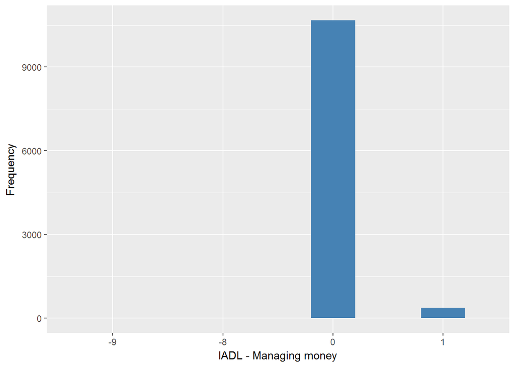

#### 2.1.4.1 Harmonisation algorithm

To compute the harmonize variable from the study-specific variable it has to be recoded as follows:

- `1 into 0`
- `0 into 1`
- `-9 Refusal into 997`
- `-8 Don't know into 998`

**R script:**

```r
ELSA_ds_w4 <- tibble(id = ELSA_w4_iadl_money$id)
ELSA_ds_w4$iadl_money <- car::recode(ELSA_w4_iadl_money$headlmo, "0 = '1';1 = '0';-9 = '997';-8 = '998';-1 = '996' ")
ELSA_ds_w4$iadl_money <- labelled(ELSA_ds_w4$iadl_money, labels = c(Yes = 0,
    No = 1, Missing = 999, Do_not_know = 998, Refuse = 997, Not_applicable = 996,
    Does_not_answer = 995, Not_attempt_not_done = 994, Disable_to_measure = 993,
    Impute = 992, CAPI_interviewer_error = 991))
```

#### 2.1.4.2 Statistical description of the new harmonised variable

| Sample size | Missing values |
| --- | --- |
| 11050 | 9 |

Category

|  | 0 | 1 |
| --- | --- | --- |
| Frequency | 368.00 | 10673.00 |
| Percentage | 3.33 | 96.59 |

Type of missing

|  | 991 | 992 | 993 | 994 | 995 | 996 | 997 | 998 | 999 | NA |
| --- | --- | --- | --- | --- | --- | --- | --- | --- | --- | --- |
| Frequency | 0 | 0 | 0 | 0 | 0 | 0 | 7.00 | 2.00 | 0 | 0 |
| Percentage | 0 | 0 | 0 | 0 | 0 | 0 | 0.06 | 0.02 | 0 | 0 |

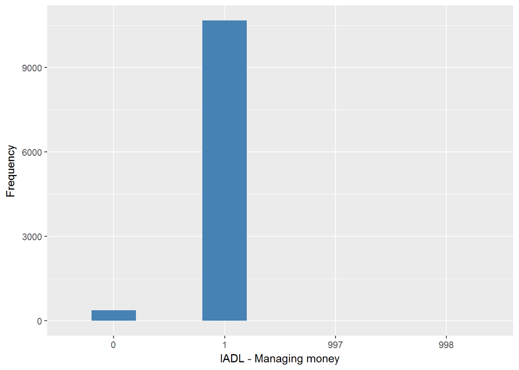

#### 2.1.4.3 Validation

|  | 1->0 | 0->1 | -9->997 | -8->998 |
| --- | --- | --- | --- | --- |
| BeforeH | 368 | 10673 | 7 | 2 |
| AfterH | 368 | 10673 | 7 | 2 |

### 2.1.5 Wave 5

- Name: `headlmo`
- Label: `IADL: Difficulty managing money, eg paying bills,keeping track expenses`
- Categories:
- `0 = Not mentioned`
- `1 = Mentioned`
- Missings
- `-9 = Refusal`
- `-8 = Don't know`

| Sample size | Missing values |
| --- | --- |
| 10274 | 0 |

Category

|  | -9 | -8 | 0 | 1 |
| --- | --- | --- | --- | --- |
| Frequency | 5.00 | 3.00 | 9885.00 | 381.00 |
| Percentage | 0.05 | 0.03 | 96.21 | 3.71 |

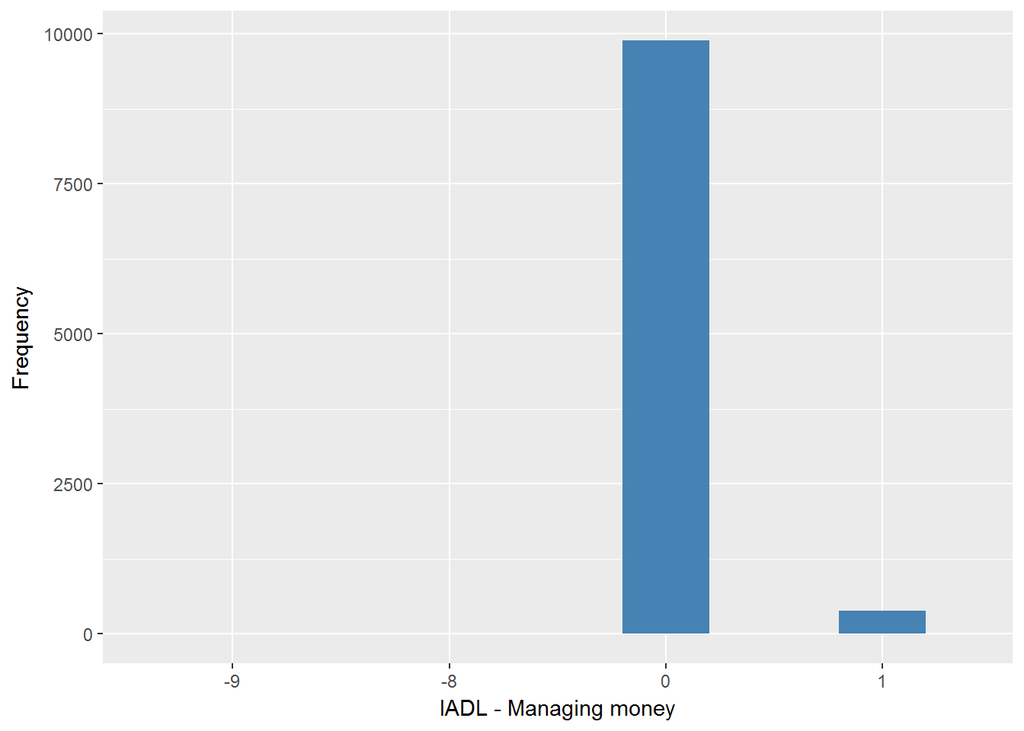

#### 2.1.5.1 Harmonisation algorithm

To compute the harmonize variable from the study-specific variable it has to be recoded as follows:

- `1 into 0`
- `0 into 1`
- `-9 Refusal into 997`
- `-8 Don't know into 998`

**R script:**

```r
ELSA_ds_w5 <- tibble(id = ELSA_w5_iadl_money$id)
ELSA_ds_w5$iadl_money <- car::recode(ELSA_w5_iadl_money$headlmo, "0 = '1';1 = '0';-9 = '997';-8 = '998';-1 = '996' ")
ELSA_ds_w5$iadl_money <- labelled(ELSA_ds_w5$iadl_money, labels = c(Yes = 0,
    No = 1, Missing = 999, Do_not_know = 998, Refuse = 997, Not_applicable = 996,
    Does_not_answer = 995, Not_attempt_not_done = 994, Disable_to_measure = 993,
    Impute = 992, CAPI_interviewer_error = 991))
```

#### 2.1.5.2 Statistical description of the new harmonised variable

| Sample size | Missing values |
| --- | --- |
| 10274 | 8 |

Category

|  | 0 | 1 |
| --- | --- | --- |
| Frequency | 381.00 | 9885.00 |
| Percentage | 3.71 | 96.21 |

Type of missing

|  | 991 | 992 | 993 | 994 | 995 | 996 | 997 | 998 | 999 | NA |
| --- | --- | --- | --- | --- | --- | --- | --- | --- | --- | --- |
| Frequency | 0 | 0 | 0 | 0 | 0 | 0 | 5.00 | 3.00 | 0 | 0 |
| Percentage | 0 | 0 | 0 | 0 | 0 | 0 | 0.05 | 0.03 | 0 | 0 |

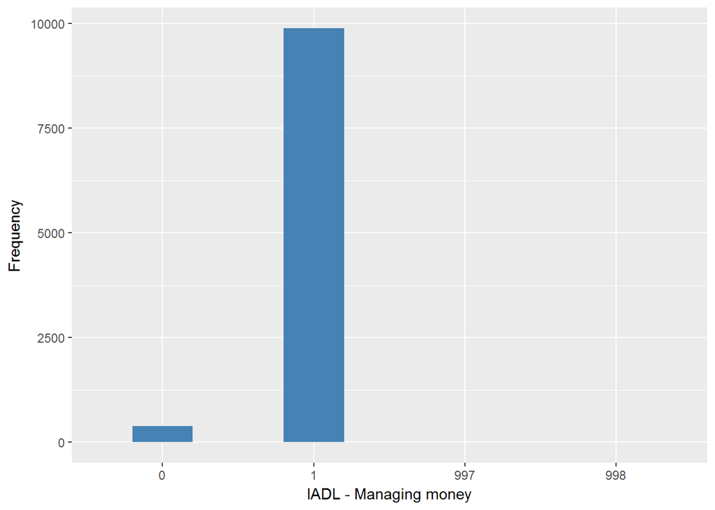

#### 2.1.5.3 Validation

|  | 1->0 | 0->1 | -9->997 | -8->998 |
| --- | --- | --- | --- | --- |
| BeforeH | 381 | 9885 | 5 | 3 |
| AfterH | 381 | 9885 | 5 | 3 |

### 2.1.6 Wave 6

- Name: `headlmo`
- Label: `IADL: Difficulty managing money, eg paying bills,keeping track expenses`
- Categories:
- `0 = Not mentioned`
- `1 = Mentioned`
- Missings
- `-9 = Refusal`
- `-8 = Don't know`

HEADLMO

| Sample size | Missing values |
| --- | --- |
| 10601 | 0 |

Category

|  | -9 | -8 | 0 | 1 |
| --- | --- | --- | --- | --- |
| Frequency | 3.00 | 2.00 | 10183.00 | 413.0 |
| Percentage | 0.03 | 0.02 | 96.06 | 3.9 |

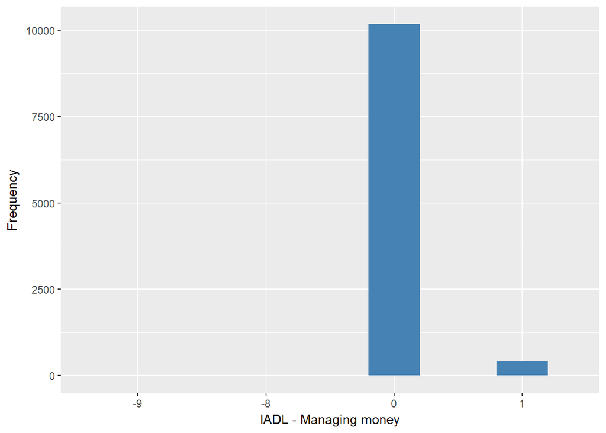

#### 2.1.6.1 Harmonisation algorithm

To compute the harmonize variable from the study-specific variable it has to be recoded as follows:

- `1 into 0`
- `0 into 1`
- `-9 Refusal into 997`
- `-8 Don't know into 998`

**R script:**

```r
ELSA_ds_w6 <- tibble(id = ELSA_w6_iadl_money$id)
ELSA_ds_w6$iadl_money <- car::recode(ELSA_w6_iadl_money$headlmo, "0 = '1';1 = '0';-9 = '997';-8 = '998';-1 = '996' ")
ELSA_ds_w6$iadl_money <- labelled(ELSA_ds_w6$iadl_money, labels = c(Yes = 0,
    No = 1, Missing = 999, Do_not_know = 998, Refuse = 997, Not_applicable = 996,
    Does_not_answer = 995, Not_attempt_not_done = 994, Disable_to_measure = 993,
    Impute = 992, CAPI_interviewer_error = 991))
```

#### 2.1.6.2 Statistical description of the new harmonised variable

| Sample size | Missing values |
| --- | --- |
| 10601 | 5 |

Category

|  | 0 | 1 |
| --- | --- | --- |
| Frequency | 413.0 | 10183.00 |
| Percentage | 3.9 | 96.06 |

Type of missing

|  | 991 | 992 | 993 | 994 | 995 | 996 | 997 | 998 | 999 | NA |
| --- | --- | --- | --- | --- | --- | --- | --- | --- | --- | --- |
| Frequency | 0 | 0 | 0 | 0 | 0 | 0 | 3.00 | 2.00 | 0 | 0 |
| Percentage | 0 | 0 | 0 | 0 | 0 | 0 | 0.03 | 0.02 | 0 | 0 |

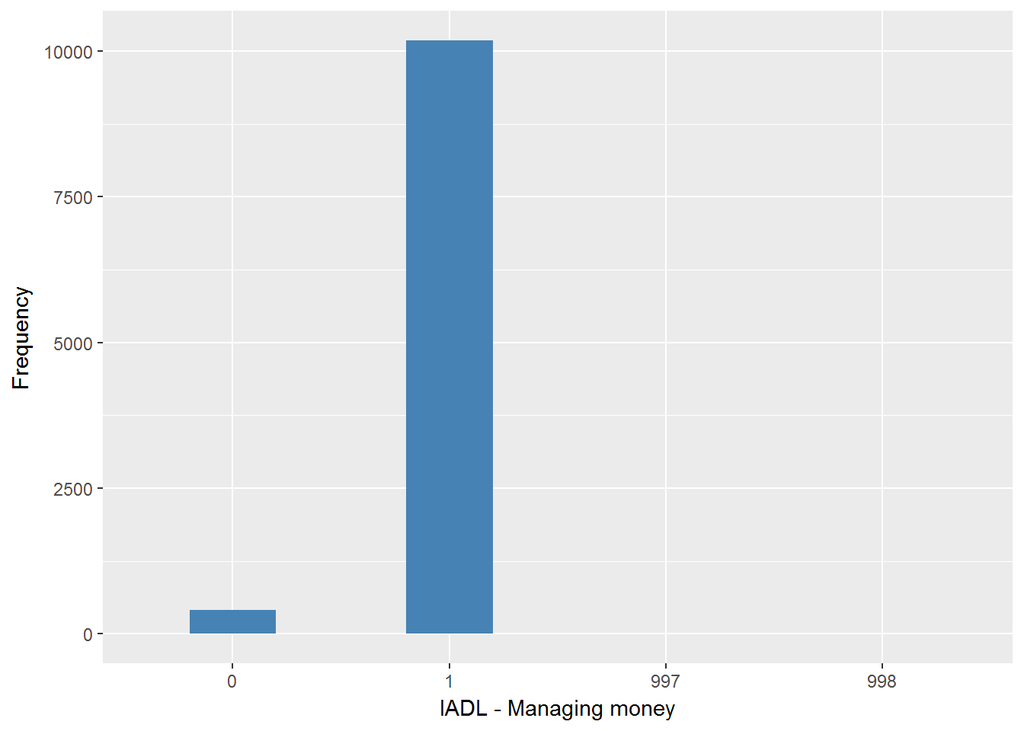

#### 2.1.6.3 Validation

|  | 1->0 | 0->1 | -9->997 | -8->998 |
| --- | --- | --- | --- | --- |
| BeforeH | 413 | 10183 | 3 | 2 |
| AfterH | 413 | 10183 | 3 | 2 |

### 2.1.7 Wave 7

- Name: `headlmo`
- Label: `IADL: Difficulty managing money, eg paying bills,keeping track expenses`
- Categories:
- `0 = Not mentioned`
- `1 = Mentioned`
- Missings
- `-8 = Don't know`

| Sample size | Missing values |
| --- | --- |
| 9666 | 0 |

Category

|  | -8 | 0 | 1 |
| --- | --- | --- | --- |
| Frequency | 2.00 | 9316.00 | 348.0 |
| Percentage | 0.02 | 96.38 | 3.6 |

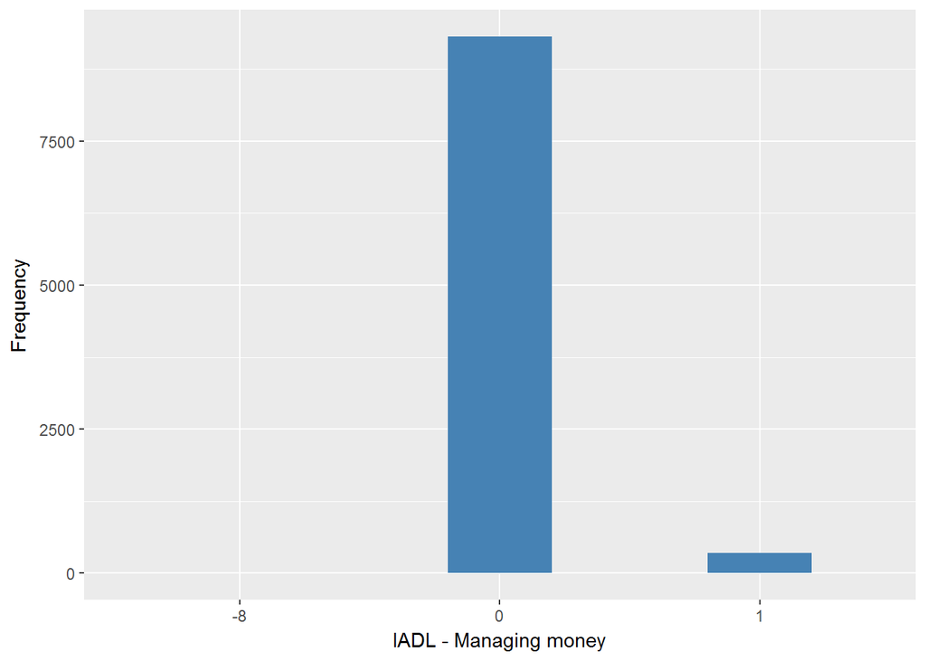

#### 2.1.7.1 Harmonisation algorithm

To compute the harmonize variable from the study-specific variable it has to be recoded as follows:

- `1 into 0`
- `0 into 1`
- `-8 Don't know into 998`

**R script:**

```r
ELSA_ds_w7 <- tibble(id = ELSA_w7_iadl_money$id)
ELSA_ds_w7$iadl_money <- car::recode(ELSA_w7_iadl_money$headlmo, "0 = '1';1 = '0';-9 = '997';-8 = '998';-1 = '996' ")
ELSA_ds_w7$iadl_money <- labelled(ELSA_ds_w7$iadl_money, labels = c(Yes = 0,
    No = 1, Missing = 999, Do_not_know = 998, Refuse = 997, Not_applicable = 996,
    Does_not_answer = 995, Not_attempt_not_done = 994, Disable_to_measure = 993,
    Impute = 992, CAPI_interviewer_error = 991))
```

#### 2.1.7.2 Statistical description of the new harmonised variable

| Sample size | Missing values |
| --- | --- |
| 9666 | 2 |

Category

|  | 0 | 1 |
| --- | --- | --- |
| Frequency | 348.0 | 9316.00 |
| Percentage | 3.6 | 96.38 |

Type of missing

|  | 991 | 992 | 993 | 994 | 995 | 996 | 997 | 998 | 999 | NA |
| --- | --- | --- | --- | --- | --- | --- | --- | --- | --- | --- |
| Frequency | 0 | 0 | 0 | 0 | 0 | 0 | 0 | 2.00 | 0 | 0 |
| Percentage | 0 | 0 | 0 | 0 | 0 | 0 | 0 | 0.02 | 0 | 0 |

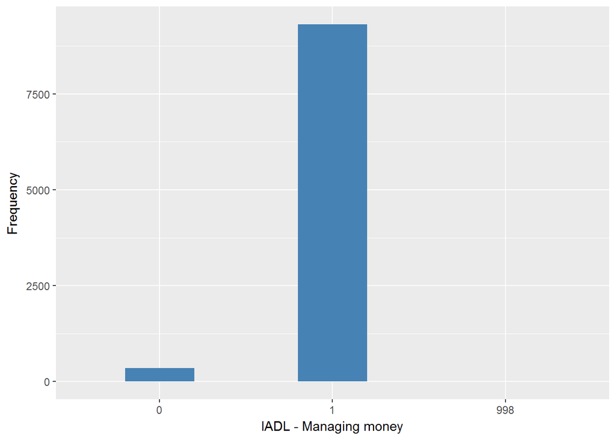

#### 2.1.7.3 Validation

|  | 1->0 | 0->1 | -8->998 |
| --- | --- | --- | --- |
| BeforeH | 348 | 9316 | 2 |
| AfterH | 348 | 9316 | 2 |

# 3 Quality estimation

No comments

## 3.1 Summary of descriptive statistics of the harmonised variable accross populations and waves

Two tables are generated:

1. Percentages of categories in each harmonised variable.
2. Frequencies and percentages of individuals with different trajectories. To avoid too large table, Only trajectories with percentages larger than 0.3 are shown.

| val | label | w1 | w2 | w3 | w4 | w5 | w6 | w7 |
| --- | --- | --- | --- | --- | --- | --- | --- | --- |
| 0 | Presence | 2.38 | 3.31 | 3.66 | 3.33 | 3.71 | 3.9 | 3.6 |
| 1 | Absence | 96.04 | 96.66 | 96.3 | 96.59 | 96.21 | 96.06 | 96.38 |
| 991 | CAPI_interviewer_error | 0 | 0 | 0 | 0 | 0 | 0 | 0 |
| 992 | Impute | 0 | 0 | 0 | 0 | 0 | 0 | 0 |
| 993 | Disable_to_measure | 0 | 0 | 0 | 0 | 0 | 0 | 0 |
| 994 | Not_attempt_not_done | 0 | 0 | 0 | 0 | 0 | 0 | 0 |
| 995 | Does_not_answer | 0 | 0 | 0 | 0 | 0 | 0 | 0 |
| 996 | Not_applicable | 1.45 | 0 | 0.04 | 0 | 0 | 0 | 0 |
| 997 | Refuse | 0.03 | 0.02 | 0 | 0.06 | 0.05 | 0.03 | 0 |
| 998 | Do_not_know | 0.1 | 0.01 | 0 | 0.02 | 0.03 | 0.02 | 0.02 |
| 999 | Missing | 0 | 0 | 0 | 0 | 0 | 0 | 0 |
| NA | NA | 0 | 0 | 0 | 0 | 0 | 0 | 0 |
| n | sample size | 12099 | 9432 | 9771 | 11050 | 10274 | 10601 | 9666 |

|  | val | frq | raw.prc |
| --- | --- | --- | --- |
| 68 | 0NANANANANANA | 101 | 0.55 |
| 180 | 1111110 | 83 | 0.45 |
| 181 | 1111111 | 4013 | 21.70 |
| 182 | 111111NA | 542 | 2.93 |
| 184 | 11111NA1 | 59 | 0.32 |
| 185 | 11111NANA | 384 | 2.08 |
| 188 | 1111NA11 | 58 | 0.31 |
| 192 | 1111NANANA | 511 | 2.76 |
| 200 | 111NA111 | 111 | 0.60 |
| 208 | 111NANANANA | 808 | 4.37 |
| 218 | 11NA1111 | 106 | 0.57 |
| 241 | 11NANANANANA | 1182 | 6.39 |
| 262 | 1NA11111 | 88 | 0.48 |
| 278 | 1NA1NANANANA | 90 | 0.49 |
| 292 | 1NANA1111 | 63 | 0.34 |
| 307 | 1NANANA111 | 56 | 0.30 |
| 315 | 1NANANANANANA | 1898 | 10.27 |
| 387 | NANA11111 | 829 | 4.48 |
| 388 | NANA1111NA | 116 | 0.63 |
| 391 | NANA111NANA | 83 | 0.45 |
| 395 | NANA11NANANA | 119 | 0.64 |
| 397 | NANA1NA111 | 57 | 0.31 |
| 404 | NANA1NANANANA | 305 | 1.65 |
| 434 | NANANA1111 | 1622 | 8.77 |
| 435 | NANANA111NA | 243 | 1.31 |
| 438 | NANANA11NANA | 176 | 0.95 |
| 443 | NANANA1NANANA | 351 | 1.90 |
| 449 | NANANANA111 | 78 | 0.42 |
| 458 | NANANANANA11 | 917 | 4.96 |
| 459 | NANANANANA1NA | 259 | 1.40 |
| 461 | NANANANANANA1 | 497 | 2.69 |
| 462 | NANANANANANANA | 92 | 0.50 |